# P4 Explore and Summarize Data

Fabio Correa Cordeiro

01/ago/2017

# Exploratory Descriptive Analysis of Congressman Local Transportation

This is Exploratory Descriptive Analisys of expendure with local transportation made with Brazilian Congressmen dataset. We worked with data generated by [Operação Serenata de Amor](https://github.com/datasciencebr/serenata-de-amor), a project that built an intelligence capable of analyzing public spending and saying, with reliability, the possibility of each receipt being unlawful. In this document, we will analyze the congressmen of Rio de Janeiro state, but when changing the variable “state_target” is possible to check the other states.

The first step is read the original data and subset the data of local transportation of all reimbursements

First of all, let’s check the distribution of the “total_net_value” of each reimbursement.

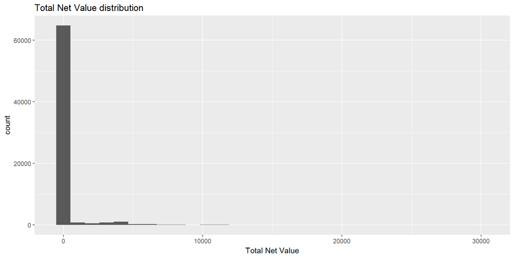

Almost all reimbursement is less than R 5.000, but there is a long tail with some expenditure near of R$ 30.000. For a better visualization of the long tail, we will use a log10 transformation on the X axis.

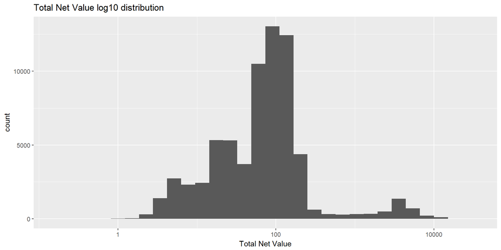

```
##     Min.  1st Qu.   Median     Mean  3rd Qu.     Max.
##     0.21    27.00    75.79   276.60   130.00 30000.00
```

Let’s see the distribution of the reimbursements by the subquotas.

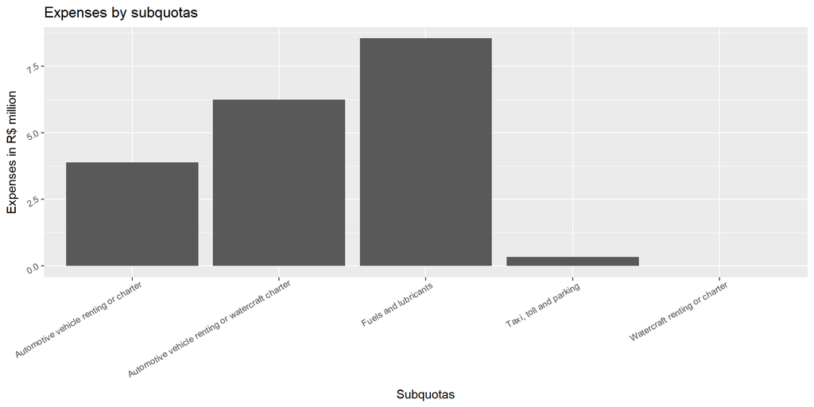

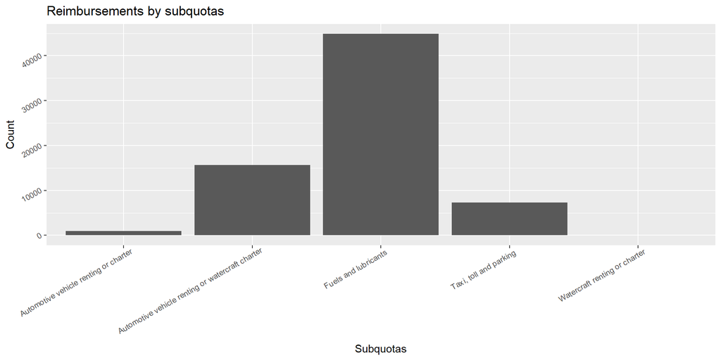

| subquota_description | total_reimbursements | total_net_value |
| --- | --- | --- |
| Automotive vehicle renting or charter | 938 | 3889009.5 |
| Automotive vehicle renting or watercraft charter | 15644 | 6238352.8 |
| Fuels and lubricants | 44840 | 8541095.4 |
| Taxi, toll and parking | 7283 | 339162.5 |
| Watercraft renting or charter | 2 | 146.0 |

Then, we will group the data by month.

And plot the sum of all expenses of all congressman per month.

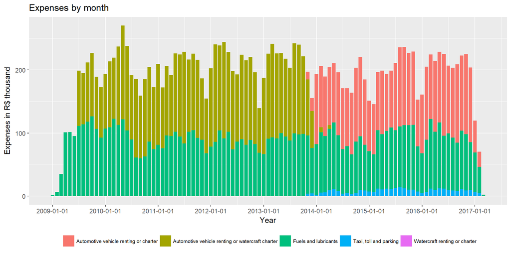

```
##    Min. 1st Qu.  Median    Mean 3rd Qu.    Max.
##      84   63150   91790   80200  107200  154200
```

In the end of 2013, we can see that subquota “Automotive vehicle renting or watercraft charter” was changed by “Automotive vehicle renting” and watercraft renting or charter“. We can observe monthly expenses about R$200.000 with a seasonal variation.

Now we will check how was the expenses of each congressperson by month.

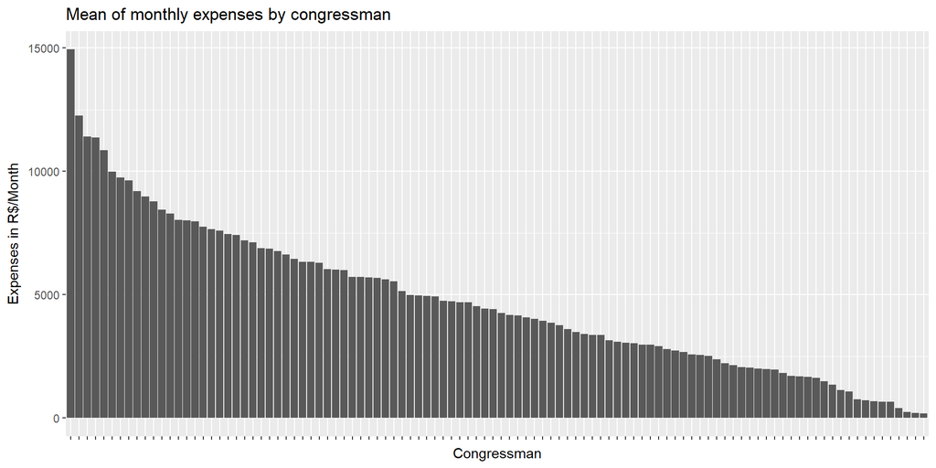

```
##    Min. 1st Qu.  Median    Mean 3rd Qu.    Max.
##   182.9  2485.0  4329.0  4739.0  6659.0 14940.0
```

The monthly expenditure with local transportation of Rio de Janeiro congressmen is very high. 75% of them spent more than R$2.400 peer month, and there is one congressman spent almost R15.000 monthly.

Let’s see more datails in the graph add the median (center dot), quantil 95% and 5% (uppeer and down limit of each bar).

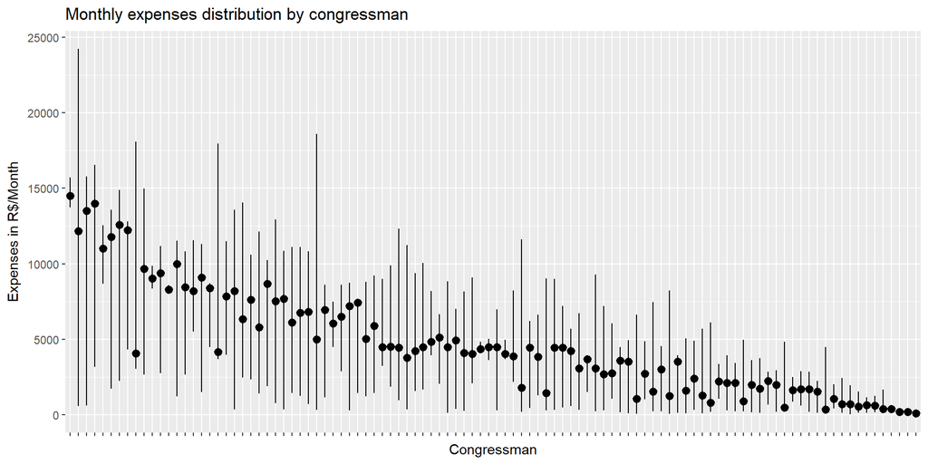

```
##  congressperson_name congressperson_id mean_net_value    median_net_value
##  Length:104          Min.   :  4928    Min.   :  182.9   Min.   :  119.6
##  Class :character    1st Qu.: 74846    1st Qu.: 2485.4   1st Qu.: 1783.4
##  Mode  :character    Median :141498    Median : 4329.4   Median : 4204.7
##                      Mean   :132500    Mean   : 4739.3   Mean   : 4709.2
##                      3rd Qu.:162589    3rd Qu.: 6658.6   3rd Qu.: 6857.9
##                      Max.   :196358    Max.   :14935.3   Max.   :14500.0
##  quantil_5percent_net_value quantil_95percent_net_value
##  Min.   :   40.19           Min.   :  191.8
##  1st Qu.:  223.56           1st Qu.: 4529.6
##  Median :  608.15           Median : 7931.2
##  Mean   : 1527.25           Mean   : 7934.0
##  3rd Qu.: 2054.33           3rd Qu.:10914.2
##  Max.   :13739.58           Max.   :24204.5
```

We can observe, even the congressmen with a low mean on “total_net_value”, in some months have high expenses.

The next step is to do the same analysis for each subquota: ‘Automotive vehicle renting or charter’, ‘Fuels and lubricants’, ‘Taxi, toll and parking’, ‘Watercraft renting or charter’ and ‘Automotive vehicle renting or watercraft charter’

### Automotive vehicle renting or charter

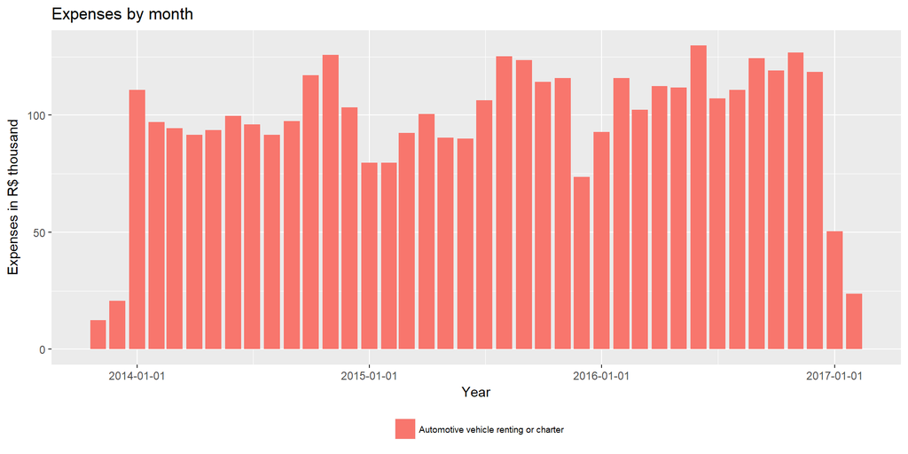

```
##    Min. 1st Qu.  Median    Mean 3rd Qu.    Max.
##   12490   91580  101400   97230  115800  129800
```

This subquota started at the end of 2013 with an annual seasonality. The mean monthly expenditure for Rio de Janeiro Congressmen is about R$100.000.

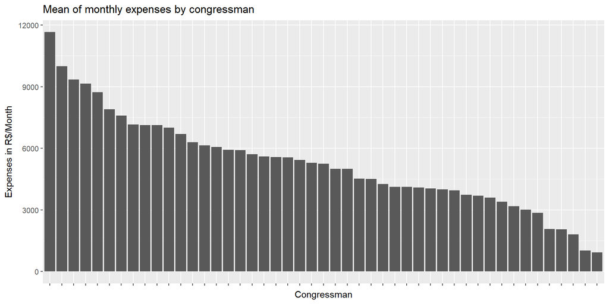

```
##    Min. 1st Qu.  Median    Mean 3rd Qu.    Max.
##   927.6  3839.0  5254.0  5259.0  6498.0 11660.0
```

It is possible to observe the same behave of the distribution in this sub quota and in the total of local transportation. More than 75% of the congressmen spent more than R$3800 per month renting a car.

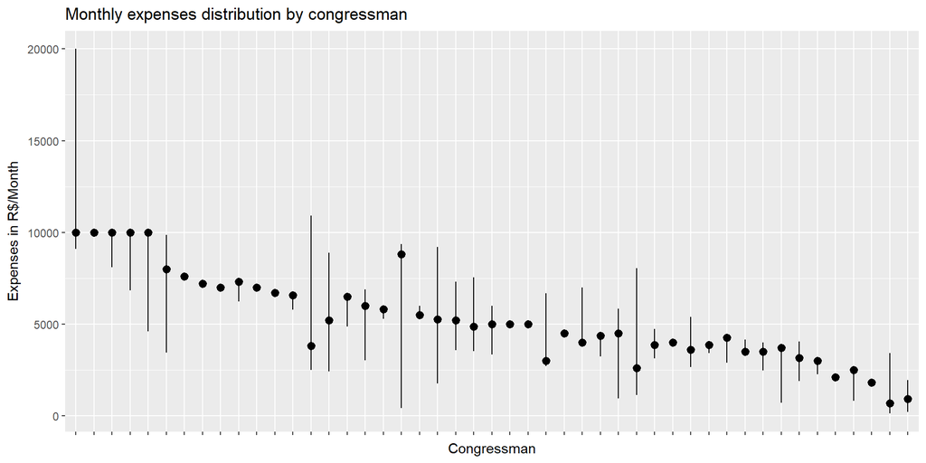

```
##  congressperson_name congressperson_id mean_net_value    median_net_value
##  Length:47           Min.   : 73424    Min.   :  927.6   Min.   :  664.5
##  Class :character    1st Qu.: 74852    1st Qu.: 3838.7   1st Qu.: 3650.0
##  Mode  :character    Median :146829    Median : 5254.3   Median : 5000.0
##                      Mean   :134527    Mean   : 5258.7   Mean   : 5246.9
##                      3rd Qu.:178885    3rd Qu.: 6498.0   3rd Qu.: 6850.0
##                      Max.   :196358    Max.   :11656.0   Max.   :10000.0
##  quantil_5percent_net_value quantil_95percent_net_value
##  Min.   :  120              Min.   : 1804
##  1st Qu.: 2337              1st Qu.: 4198
##  Median : 3427              Median : 6500
##  Mean   : 3907              Mean   : 6453
##  3rd Qu.: 5389              3rd Qu.: 7560
##  Max.   :10000              Max.   :20000
```

In this chart we found one outlier big outlier, a R$20,000 expenditure with rent a car.

### Fuels and lubricants

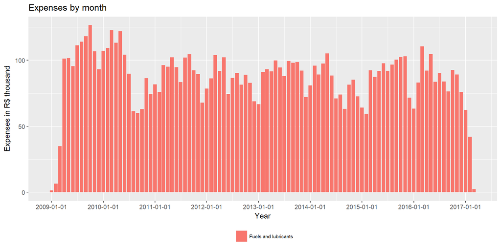

```
##    Min. 1st Qu.  Median    Mean 3rd Qu.    Max.
##    1394   76110   90350   86270   99530  126600
```

The monthly expenditure with fuel by Rio de Janeiro Congressmen is about R$90,000 with the same annual seasonality.

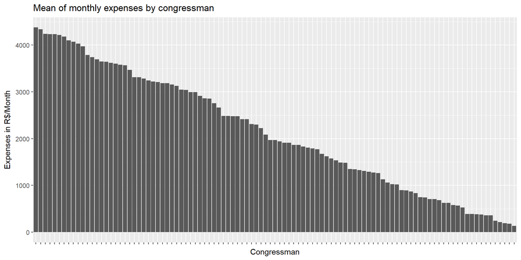

```
##    Min. 1st Qu.  Median    Mean 3rd Qu.    Max.
##   134.2  1023.0  1969.0  2146.0  3215.0  4376.0
```

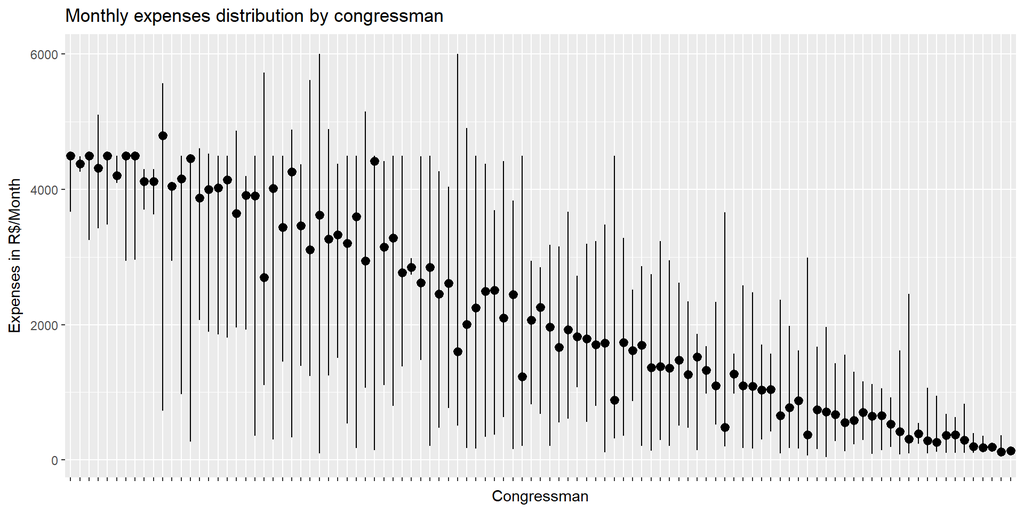

```
##  congressperson_name congressperson_id mean_net_value   median_net_value
##  Length:103          Min.   :  4928    Min.   : 134.2   Min.   : 119.6
##  Class :character    1st Qu.: 74848    1st Qu.:1023.1   1st Qu.: 824.4
##  Mode  :character    Median :141501    Median :1969.0   Median :1929.3
##                      Mean   :133060    Mean   :2146.4   Mean   :2184.1
##                      3rd Qu.:163003    3rd Qu.:3215.3   3rd Qu.:3533.0
##                      Max.   :196358    Max.   :4376.1   Max.   :4800.0
##  quantil_5percent_net_value quantil_95percent_net_value
##  Min.   :  40.19            Min.   : 157.4
##  1st Qu.: 168.95            1st Qu.:1914.4
##  Median : 356.47            Median :3661.4
##  Mean   : 879.48            Mean   :3256.1
##  3rd Qu.:1103.25            3rd Qu.:4500.0
##  Max.   :4262.74            Max.   :6000.0
```

Analyzing the last two charts we can observe a very variability between the congressmen and between the expenses of the same congressman.

### Taxi, toll and parking

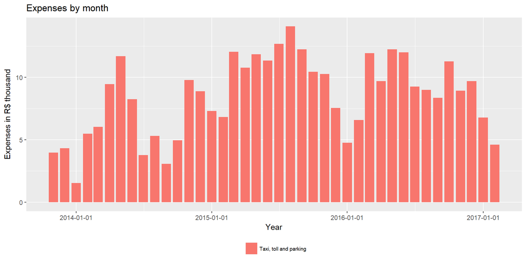

```
##    Min. 1st Qu.  Median    Mean 3rd Qu.    Max.
##    1542    5906    8958    8479   11300   14090
```

The taxi subquota started at the end of 2013 and increase in the following years.

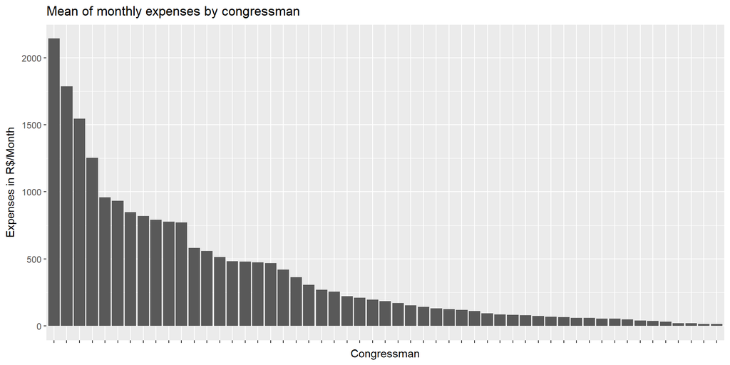

```
##    Min. 1st Qu.  Median    Mean 3rd Qu.    Max.
##    15.5    68.6   185.0   388.2   514.6  2143.0
```

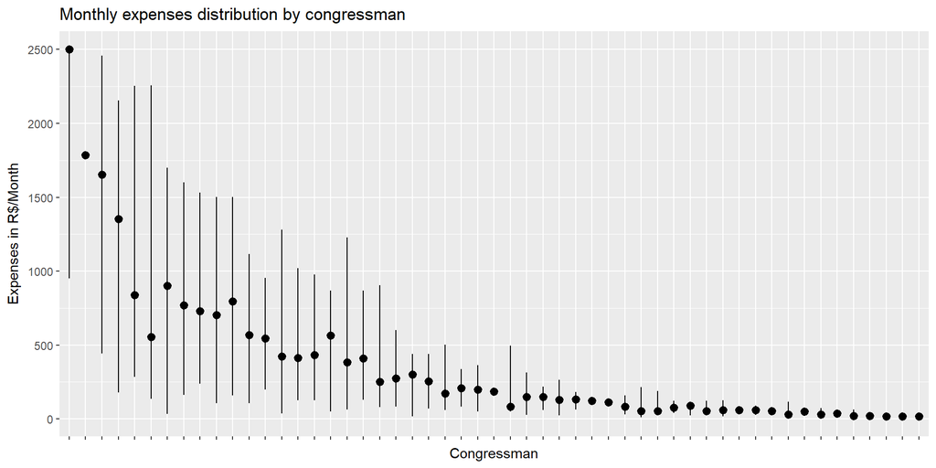

```
##  congressperson_name congressperson_id mean_net_value   median_net_value
##  Length:53           Min.   : 72912    Min.   :  15.5   Min.   :  15.50
##  Class :character    1st Qu.:116663    1st Qu.:  68.6   1st Qu.:  58.95
##  Mode  :character    Median :160577    Median : 185.0   Median : 170.79
##                      Mean   :142616    Mean   : 388.2   Mean   : 375.82
##                      3rd Qu.:178936    3rd Qu.: 514.6   3rd Qu.: 544.00
##                      Max.   :196358    Max.   :2142.9   Max.   :2500.00
##  quantil_5percent_net_value quantil_95percent_net_value
##  Min.   :   6.5             Min.   :  15.5
##  1st Qu.:  27.9             1st Qu.: 117.0
##  Median :  54.4             Median : 335.9
##  Mean   : 129.7             Mean   : 693.3
##  3rd Qu.: 125.2             3rd Qu.:1116.3
##  Max.   :1787.0             Max.   :2500.0
```

We can see two groups of Congressmen, one has monthly expenses with taxi below of R$250 and small variability. The second group has much bigger expenses and variability, with max monthly expenses in R2,500.

### Watercraft renting or charter

The Rio de Janeiro congressmen have only two reimbursements for watercraft renting or charter, so we don’t will analyzing this subquota.

### Automotive vehicle renting or watercraft charter

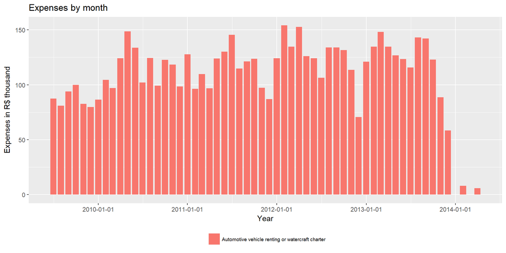

```
##    Min. 1st Qu.  Median    Mean 3rd Qu.    Max.
##      84   96900  121000  109400  130000  154200
```

The subquota “Automotive vehicle renting or watercraft charter” started in 2009 and finished in the end of 2013. The mean value increased over time, and the final mean value is similar of the subquota “Automotive vehicle renting or charter” which replaced it.

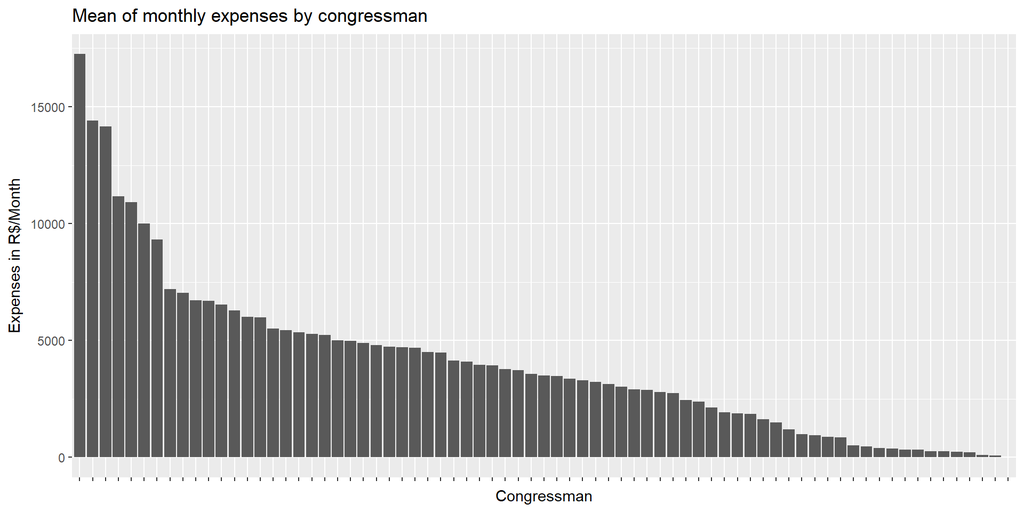

```
##    Min. 1st Qu.  Median    Mean 3rd Qu.    Max.
##      15    1484    3501    4037    5285   17250
```

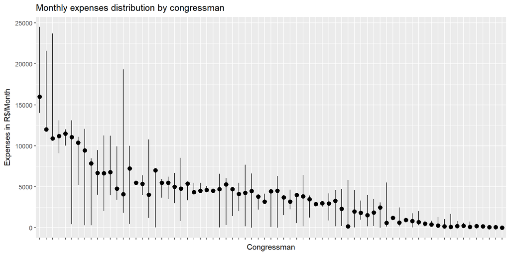

```
##  congressperson_name congressperson_id mean_net_value  median_net_value
##  Length:73           Min.   :  4928    Min.   :   15   Min.   :   15.0
##  Class :character    1st Qu.: 74833    1st Qu.: 1484   1st Qu.:  947.5
##  Mode  :character    Median :141419    Median : 3501   Median : 4000.0
##                      Mean   :120775    Mean   : 4037   Mean   : 4053.9
##                      3rd Qu.:152605    3rd Qu.: 5285   3rd Qu.: 5355.0
##                      Max.   :171622    Max.   :17250   Max.   :16000.0
##  quantil_5percent_net_value quantil_95percent_net_value
##  Min.   :    4.6            Min.   :   15
##  1st Qu.:  107.7            1st Qu.: 2900
##  Median :  568.0            Median : 4903
##  Mean   : 2027.8            Mean   : 6031
##  3rd Qu.: 3200.0            3rd Qu.: 7082
##  Max.   :14000.0            Max.   :24500
```

How occurred in the previews subquotas, there is a variety of congressmen behavior. There are some congressmen spent few reais per month and other more than R$15,000 (with outliers of almost R25,000).

# Suspicious reimbursements

Finally, we will be looking for suspicious reimbursements in only one subquota. We choose ‘Fuels and lubricants’ because is easier transform the expenses in an objective product. We will try to find some suspect reimbursements in subquota “Fuel and lubricants” using the worst case acceptable. We will find a limit to expenses, any reimbursement greater than this limit we will consider a suspect reimbursement.

### We will consider suspecting all reimbursements that exceed the max cost of R$917.00.

The max cost was calculate using the worst case that is possible to fill a gas and lubricant tank of a car. We used the biggest gas tank in Brazilian market (Ford F-250 with 110l tank), the cost of gas in the most expense gas station in Brazil (R4.70) and 10l of most expensive lubricant (R$40.00). Most of the service stations don’t charge to change lubricants.

Sources:

[Cost of gas](http://www.anp.gov.br/preco/prc/Resumo_Semanal_Combustiveis.asp%20in%2025/apr/2017)

[Lubricant capacity](http://www.autoideia.com.br/capacidade_oleo_motor_automoveis&codmar=ford)

[Cost of lubricant](http://www.mercadomineiro.com.br/pesquisa/oleo-lubrificante-pesquisa-precos)

[Tanks size](https://panelinhanet.wordpress.com/2013/02/20/combustivel-quantos-litros-cabem-no-tanque-do-seu-veiculo/) in 18/mar/2017

```
## [1] 917
```

Now, let’s plot the distribution of these supect reimbursements.

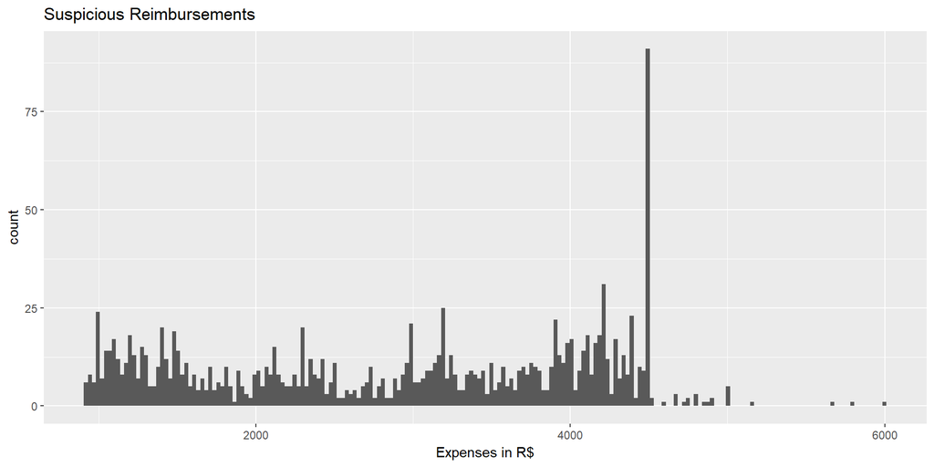

```
##    Min. 1st Qu.  Median    Mean 3rd Qu.    Max.
##     920    1746    3063    2901    4000    6000
```

```
## [1] 4002959
```

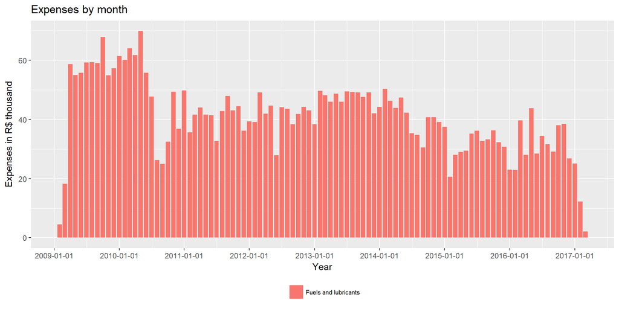

```
##    Min. 1st Qu.  Median    Mean 3rd Qu.    Max.
##    2069   32790   41750   40850   48530   69940
```

When we see the distribution of the suspects by month, we realized that the Brazilian people pay every month about R$40.000 in fraud or mistakes, only in this subquota for Rio de Janeiro Congressmen.

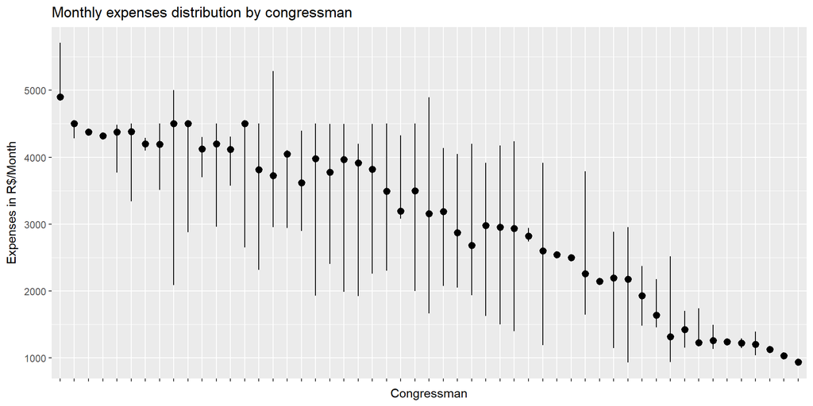

```
##  congressperson_name congressperson_id mean_net_value   median_net_value
##  Length:53           Min.   :  4928    Min.   : 952.7   Min.   : 939
##  Class :character    1st Qu.: 74830    1st Qu.:2129.9   1st Qu.:2174
##  Mode  :character    Median :141433    Median :3182.7   Median :3189
##                      Mean   :122778    Mean   :2995.1   Mean   :3049
##                      3rd Qu.:160512    3rd Qu.:3898.7   3rd Qu.:4118
##                      Max.   :191945    Max.   :5181.0   Max.   :4902
##  quantil_5percent_net_value quantil_95percent_net_value
##  Min.   : 929.6             Min.   : 980.6
##  1st Qu.:1400.5             1st Qu.:2516.1
##  Median :2076.6             Median :4202.1
##  Mean   :2269.6             Mean   :3585.0
##  3rd Qu.:2940.0             3rd Qu.:4500.0
##  Max.   :4850.2             Max.   :5707.4
```

Finally, we can observe how systematic is the behave of this 53 suspect congressmen.

# Final Plots and Summary

In this exploratory analysis we checked the expenses made by Rio de Janeiro Congressmen in local transportation. The reimbursements are grouped in five subquotas. Initially, there were only two subquotas, “Fuel and Lubricant” and “Automotive Vehicle renting and watercraft charter”. Near of 2014 there were some changes in the legislation, “Taxi, toll and parking” was created and Cars and Watercrafts renting were split.

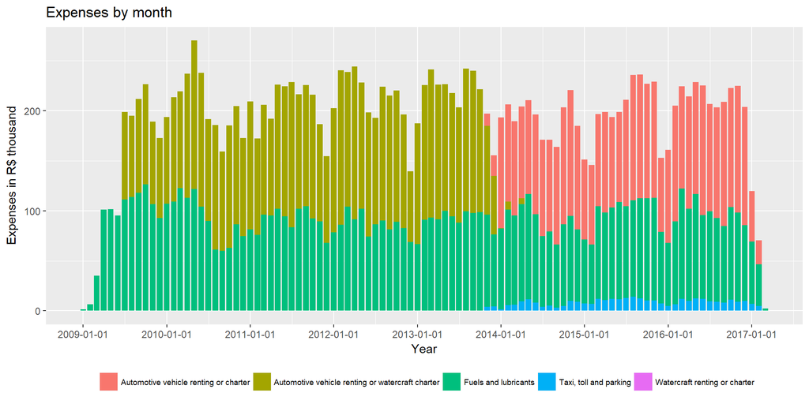

Every month these congressmen spent about R$200,000 with local transportation. Almost all services in “Automotive Vehicle renting and watercraft charter” was to rent a car, very few congressmen in Rio de Janeiro rent a boat. “Taxi, toll and parking” were cheaperservices, so has a smaller impact.

We choose the “Fuel and lubricant” subquotas for a detailed view of how was the mean expenditure of each congressman because they were more constant along the time.

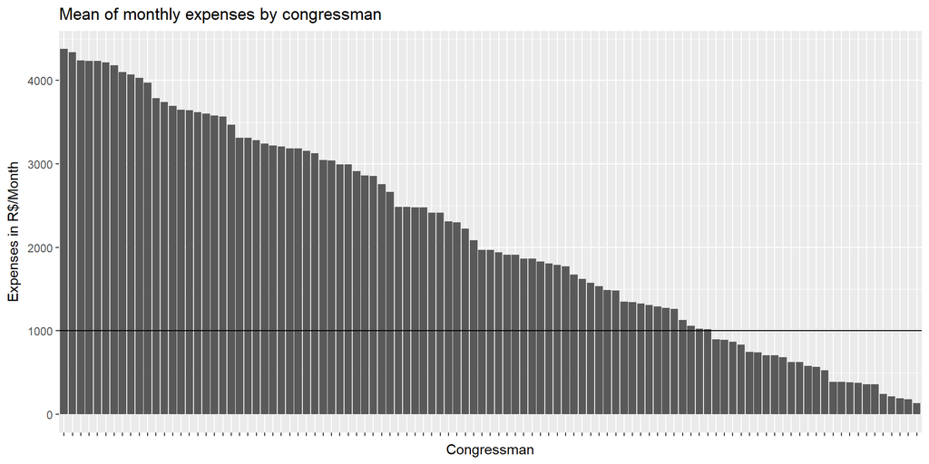

```
##    Min. 1st Qu.  Median    Mean 3rd Qu.    Max.
##   134.2  1023.0  1969.0  2146.0  3215.0  4376.0
```

75% of Rio de Janeiro Congressmen spent more than R$1000 per month in fuel, it is a value very high if we compare with expenses of ordinary people.

So, we decided looking for suspicious reimbursements in “Fuel and lubricant” subquota. We considered suspecting all reimbursements that exceed the max cost of R$917.00.

The max cost was calculated using the worst case that is possible to fill a gas and lubricant tank of a car. We used the biggest gas tank in Brazilian market (Ford F-250 with 110l tank), the cost of gas in the most expense gas station in Brazil (R4.70) and 10l of most expensive lubricant (R$40.00).

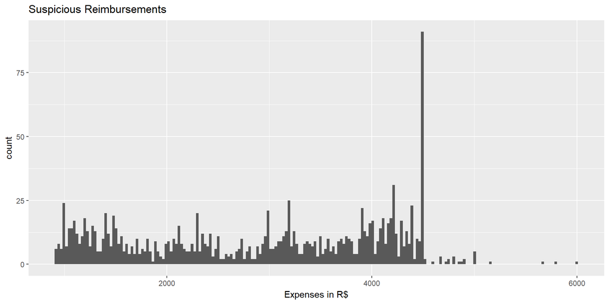

```
##    Min. 1st Qu.  Median    Mean 3rd Qu.    Max.
##     920    1746    3063    2901    4000    6000
```

```
## [1] "Total: "
```

```
## [1] 4002959
```

```
## [1] "length: "
```

```
## [1] 1380
```

In this chart, we plot every reibursement that a Rio de Janeiro Congressmen got when fill a gas tank and paid more that is possible. Considering R$917 the maximum cost of a fuel reimbursement, we found 1,380 suspicious reimbursement, tt represents R4,002,959 since 2009.

From 2009 to 2013, when this legislation was changed, the alowed limit in this subquota was R$4500, exactly the value of the big bar that we can see on the chart. Today the limit is R6000. We suspect that there are several congressmen who get a false receipt and get a reimbursement of all value allowed.

# Reflection

In this project we parse a huge dataset of Brazilian Congressmen expenses. We need to choose what kind of expenses we would like investigate. We choose the local transportation because urban mobility is a big problem in Brazil, especially in the big cities.

In the first time we analyzed all states, but there were a lot of congressmen in the plot. Then the focus changed for only one state, Rio de Janeiro.

We could found 1380 (R$4 millions) of suspicious reimbursements since 2009. This is an example how mistakes and small frauds could become a big loss for the people. The next step is to make a good data visualization to show these suspects to the public.

We were conservative in this values, we used a very high value to fill a gas tank, the most people expend much less in them cars. In the same way, we didn’t consider inflation, if we did, the number of suspicious reimbursements would be bigger than we found.

We have analyzed only a small part of the database, a similar work could be done on the others states and subquotas. The [Operação Serenata de Amor](https://github.com/datasciencebr/serenata-de-amor) team are working on several others kinds of suspects.